# Reproducible Research: Peer Assessment 1

#### Notes

- Uses `dplyr` and `ggplot2` packages

## Loading and preprocessing the data

1. Load the data

```r
setwd("/Volumes/RMS/Data Science/Coursera/Reproducible_Research/Assignment_1")
allData <- read.csv("activity.csv", header = T)
```

2. Process/transform the data (if necessary) into a format suitable for your analysis
- adds POSIX column

```r
allData$DateTime <- strptime(paste(allData$date, sprintf("%04d", allData$interval)), format = "%Y-%m-%d %H%M")
```

## What is mean total number of steps taken per day?

```r
require(dplyr); require(lubridate)
```

1. Calculate the total number of steps taken per day

```r
daily_steps <- group_by(allData[1:3], date) %>% select(date, steps) %>% summarize(steps = sum(steps, na.rm = T))
```

2. Make a histogram of the total number of steps taken each day

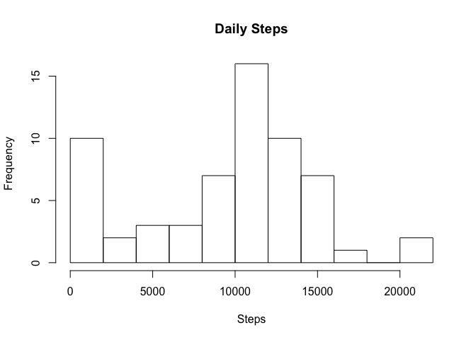

```r
hist(daily_steps$steps, breaks = 10, main = "Daily Steps", xlab = "Steps")
```

3. Calculate and report the mean and median of the total number of steps taken per day

```r
daily_mean <- mean(daily_steps$steps)
daily_median <- median(daily_steps$steps)
```

The mean number of steps taken per day was 9354.2295082

The median number of steps taken per day was 10395

## What is the average daily activity pattern?

1. Make a time series plot (i.e. `type = 'l'`) of the 5-minute interval (x-axis ) and the average number of steps taken, averaged across all days (y-axis)

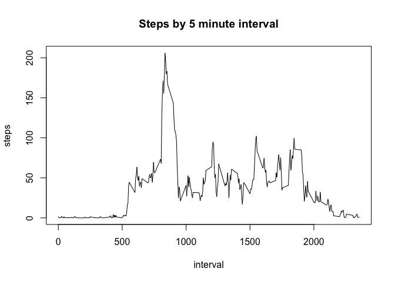

```r
minute_avg <- group_by(allData[,1:3], interval) %>% select(interval, steps) %>% summarize(steps = mean(steps, na.rm = T))

plot(minute_avg, type = "l", main = "Steps by 5 minute interval")
```

2. Which 5-minute interval, on average across all the days in the dataset, contains the maximum number of steps?

```r
head(minute_avg[order(minute_avg$steps, decreasing = T),],1)
```

```
## Source: local data frame [1 x 2]
##
##   interval    steps
## 1      835 206.1698
```

Interval 835 contains the maximum number of steps.

## Imputing missing values

1. Calculate and report the total number of missing values in the dataset (i.e. the total number of rows with NAs)

```r
sum(is.na(allData$steps))
```

```
## [1] 2304
```

2. Devise a strategy for filling in all of the missing values in the dataset. The strategy does not need to be sophisticated. For example, you could use the mean/median for that day, or the mean for that 5-minute interval, etc.

I’m going to just use the minute average to fill in missing

3. Create a new dataset that is equal to the original dataset but with the missing data filled in.

```r
# duplicate data
allData2 <- allData
# minute avg col (with replication)
allData2$minute_avg <- minute_avg$steps
# fill in NAs
allData2$steps[is.na(allData2$steps)] <- allData2$minute_avg[is.na(allData2$steps)]
# remove minute_avg col
allData2 <- allData2[,1:4]
```

4. Make a histogram of the total number of steps taken each day and Calculate and report the mean and median total number of steps taken per day. Do these values differ from the estimates from the first part of the assignment? What is the impact of imputing missing data on the estimates of the total daily number of steps?

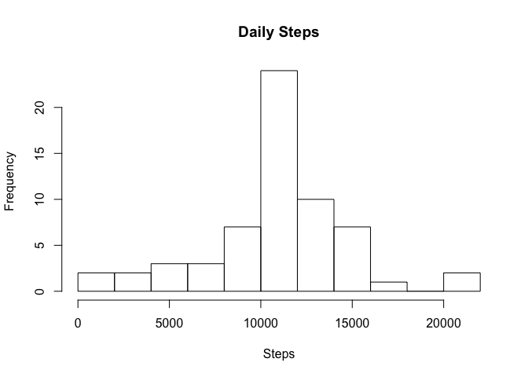

```r
new_daily_steps <- group_by(allData2[1:3], date) %>% select(date, steps) %>% summarize(steps = sum(steps, na.rm = T))

# histogram of the number of steps
hist(new_daily_steps$steps, breaks = 10, main = "Daily Steps", xlab = "Steps")
```

```r
# calculate and report the mean and median
new_daily_mean <- mean(new_daily_steps$steps)
new_daily_median <- median(new_daily_steps$steps)
```

```r
# do these values differ from the previous estimates
new_daily_mean - daily_mean
```

```
## [1] 1411.959
```

```r
new_daily_median - daily_median
```

```
## [1] 371.1887
```

These differ from the estimates from the first part of the assignment.

```r
# What is the impact of imputing missing data on the estimates of the total daily number of steps?
all_daily_steps <- cbind(daily_steps, new_steps = new_daily_steps$steps)
mutate(all_daily_steps, impact = new_steps - steps)
```

```
##          date steps new_steps   impact
## 1  2012-10-01     0  10766.19 10766.19
## 2  2012-10-02   126    126.00     0.00
## 3  2012-10-03 11352  11352.00     0.00
## 4  2012-10-04 12116  12116.00     0.00
## 5  2012-10-05 13294  13294.00     0.00
## 6  2012-10-06 15420  15420.00     0.00
## 7  2012-10-07 11015  11015.00     0.00
## 8  2012-10-08     0  10766.19 10766.19
## 9  2012-10-09 12811  12811.00     0.00
## 10 2012-10-10  9900   9900.00     0.00
## 11 2012-10-11 10304  10304.00     0.00
## 12 2012-10-12 17382  17382.00     0.00
## 13 2012-10-13 12426  12426.00     0.00
## 14 2012-10-14 15098  15098.00     0.00
```

[output cut: 47 more lines]

## Are there differences in activity patterns between weekdays and weekends?

1. Create a new factor variable in the dataset with two levels – “weekday” and “weekend” indicating whether a given date is a weekday or weekend day.

```r
# weekday function
wkd.f <- function(day) {
  if(day=="Saturday" | day == "Sunday") {
    return("weekend")
    } else {
    return("weekday")
    }
}
```

```r
# add weekend / weekday factor variable
allData2$weekday <- factor(sapply(weekdays(allData2$DateTime), wkd.f))
```

2. Make a panel plot containing a time series plot (i.e. type = “l”) of the 5-minute interval (x-axis) and the average number of steps taken, averaged across all weekday days or weekend days (y-axis). See the README file in the GitHub repository to see an example of what this plot should look like using simulated data.

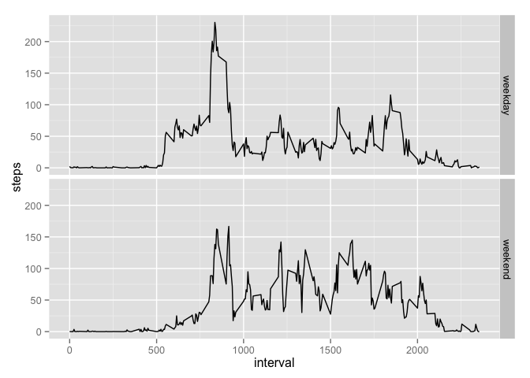

```r
require(ggplot2)
# dataset averaged across minute by factor weekday
wkdy.f_minute_avg <- group_by(allData2[,c(1:3,5)], weekday, interval) %>% summarize(steps = mean(steps))

ggplot(wkdy.f_minute_avg, aes(x = interval, y = steps)) + geom_line() + facet_grid(weekday ~ .)
```